# Figure components for creb3l3

Cat Brown

# Load libraries

```r
library(dplyr)
library(Seurat)
library(patchwork)
library(ggplot2)
library(tidyverse)
library(writexl)
library(readxl)
library(cowplot)
library(svglite)
library(pheatmap)
library(ggVennDiagram)
library(DESeq2)
library(biomaRt)
library(RColorBrewer)
```

```r
library(ggtext)
```

# Read in Creb3l3 larval bulk RNA-seq data

```r
countData <- read.csv('C:/Users/cat14/OneDrive - Johns Hopkins/Farber_Lab/Atlas paper/Figure Folders for Server-Lab/Fig 6 - creb3l3/salmon.merged.gene_counts.tsv',
                           header = TRUE,
                           sep = "\t",
                           row.names = "gene_id")
```

# Set up metadata for count data

```r
cnames <- colnames(countData)
Condition <- c("HLM Fed", "HLM Fed", "HLM Fed", "Unfed","Unfed","Unfed", "HLM Fed", "HLM Fed", "HLM Fed", "Unfed","Unfed","Unfed")
Genotype <- c("creb3l3(-/-)","creb3l3(-/-)","creb3l3(-/-)","creb3l3(-/-)","creb3l3(-/-)","creb3l3(-/-)","creb3l3(+/-)","creb3l3(+/-)","creb3l3(+/-)","creb3l3(+/-)","creb3l3(+/-)","creb3l3(+/-)")
columnData <- tibble(cnames, Condition, Genotype) %>%
  column_to_rownames(var = "cnames")
```

# Read in genes with significant main effect of genotype

```r
creb_DE <- read.csv("260723_creb3l3_bulk_DE_genotype_main_effect_sig_hits.csv")
```

# Get updated gene names for the DEGs

```r
mart <- useMart(biomart = "ENSEMBL_MART_ENSEMBL", dataset = "drerio_gene_ensembl", host ="https://dec2021.archive.ensembl.org")
gene_info <- getBM(filters = "ensembl_gene_id",
                   attributes= c("ensembl_gene_id", "external_gene_name"),
                   values = creb_DE$ensembl_gene_id,
                   mart = mart)
```

# Get the one gene that didn’t pull correctly

```r
gene_info[54, "external_gene_name"] <- "si:ch211-216l23.1"
```

# Fix apoa4b.2 to match atlas

```r
gene_info[19, "external_gene_name"] <- "apoa4b.2.1"
```

# Heatmap of count Data for these genes

## Make matrix of counts of relvant genes

```r
count_matrix <- countData %>% rownames_to_column(var = "ensembl_gene_id") %>%
  filter(ensembl_gene_id %in% creb_DE$ensembl_gene_id) %>% left_join(gene_info) %>%
  dplyr::select(!ensembl_gene_id) %>% column_to_rownames(var = "external_gene_name") %>%
  as.matrix()
```

# Use a max divided normalization instead of the z-score

```r
max_exp_df<- as.data.frame(count_matrix) %>%
  rowwise() %>% summarize(Maximum = max(c_across(1:12)))
creb_matrix_max_divided <- as.data.frame(count_matrix) / unlist(max_exp_df)
creb_matrix_max_divided <- as.matrix(creb_matrix_max_divided)
```

# Reorder matrix columns to the order desired for plotting

```r
column_order <- c("wt_nf_R1", "wt_nf_R2", "wt_nf_R3", "wt_hf_R1", "wt_hf_R2", "wt_hf_R3", "mut_nf_R1", "mut_nf_R2", "mut_nf_R3", "mut_hf_R1", "mut_hf_R2", "mut_hf_R3")
creb_matrix_max_divided <- creb_matrix_max_divided[,column_order]
```

# Plot it

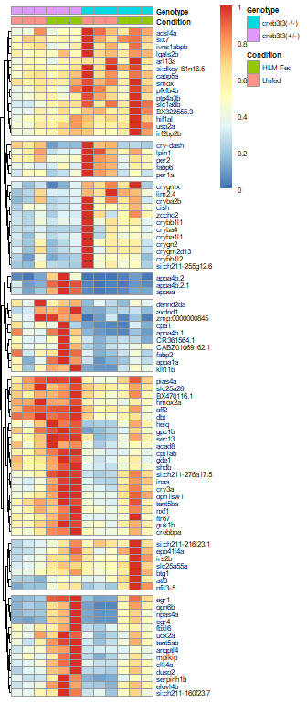

```r
h1 <- pheatmap(creb_matrix_max_divided, cluster_cols = FALSE, annotation_col = columnData, scale = "none", cutree_rows = 8, fontsize = 6, treeheight_row = 4, show_colnames = FALSE)
```

# Get the groupings

```r
creb_groups = cutree(h1$tree_row,8)
creb_groups = data.frame(creb_groups)
rownames(creb_groups) = rownames(creb_matrix_max_divided)
```

# Name the groupings

```r
creb_groups <- creb_groups %>% mutate(Creb3l3_deletion_response  = case_when(
  creb_groups == 1 ~ "Upregulated HLM Downregulated",
  creb_groups == 2 ~ "Upregulated not HLM Responsive",
  creb_groups == 3 ~ "Downregulated Uniformly",
  creb_groups == 4 ~ "Blunted HLM Induction",
  creb_groups == 5 ~ "Eliminated HLM Induction",
  creb_groups == 6 ~ "Upregulated not HLM Responsive",
  creb_groups == 7 ~ "Upregulated HLM Induced",
  creb_groups == 8 ~ "Eliminated HLM Induction"
)) %>% dplyr::select(!creb_groups)
```

# Set up colors

```r
genotype_colors <- c("creb3l3(-/-)" = "#1b9e77", "creb3l3(+/-)" = "#d95f02")
creb_response_colors <- c("Upregulated HLM Downregulated" = "#7570b3", "Upregulated not HLM Responsive" = "#e7298a", "Downregulated Uniformly" = "#66a61e", "Blunted HLM Induction" = "#E6ab02", "Eliminated HLM Induction" = "#a6761d", "Upregulated HLM Induced" = "#666666", "creb3l3 paralog" = "lightgrey")
DEG_status_colors <- c("Not LRT DEG" = "#984ea3", "Both paralog expression LRT DEG" = "#377eb8", "creb3l3b expression cluster LRT DEG" = "#4daf4a", "No creb3l3 expression cluster LRT DEG" = "#e41a1c")
Expression_location_colors <- c("Both paralog expression region" = "#a6cee3", "creb3l3b expression region" = "#b2df8a", "No creb3l3 expression region" = "#fb9a99", "creb3l3 paralog" = "lightgrey")
```

# Determine LRT DEG status

## Read in LRT DE

```r
LRT <- read.csv("C:/Users/cat14/OneDrive - Johns Hopkins/Farber_Lab/Atlas paper/Figure Folders for Server-Lab/Sup Data - DEGs LRT and pairwise/251211_DESeq_LRT_all_times_filtered_DE_results.csv")
```

## Get aEC DEGs

```r
aEC_genes <- LRT %>% filter(celltype %in% c("EnteroAnte-1", "EnteroAnte-2", "EnteroAnte-3")) %>% dplyr::select("gene") %>% unique() %>% unlist()
```

## Get other creb3l3b DEGs

```r
creb3l3b_DEGs <- LRT %>% filter(celltype %in% c("Hepatocyte-4", "CardiacMus-185", "Colangio-52", "EnBestOtop-17", "Ileocyte-15")) %>% dplyr::select("gene") %>% unique() %>% unlist() %>% setdiff(aEC_genes)
```

## Get unique LRT genes that aren’t in those clusters

```r
genes <- LRT %>% dplyr::select("gene") %>% unique() %>% unlist() %>% setdiff(aEC_genes) %>% setdiff(creb3l3b_DEGs)
```

## Make data frame that tags each creb gene with it’s group and if it is LRT

```r
creb_groups <- creb_groups %>% rownames_to_column(var = "gene") %>% mutate(LRT_status = case_when(
  gene %in% genes ~ "No creb3l3 expression cluster LRT DEG",
  gene %in% aEC_genes ~ "Both paralog expression LRT DEG",
  gene %in% creb3l3b_DEGs ~ "creb3l3b expression cluster LRT DEG",
  .default = "Not LRT DEG"
))
```

```r
creb_groups <- column_to_rownames(creb_groups, var = "gene")
```

# Plot it

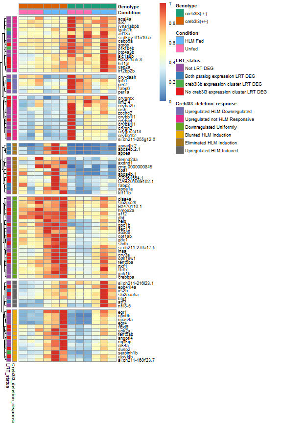

```r
h2 <- pheatmap(creb_matrix_max_divided, cluster_cols = FALSE, annotation_col = columnData, annotation_row = creb_groups, scale = "none", cutree_rows = 8, fontsize = 7, treeheight_row = 4, show_colnames = FALSE, annotation_colors = list(Genotype = genotype_colors, Condition = c("HLM Fed" = "steelblue1", "Unfed" = "hotpink1"), Creb3l3_deletion_response = creb_response_colors, LRT_status = DEG_status_colors))
```

# Read in the atlas

```r
atlas <- readRDS("C:/Users/cat14/OneDrive - Johns Hopkins/Farber_Lab/Basecaller contents/atlas_paper/251119_atlas_v2_with_cell_cycle_score_info.rds")
```

# Make scatter plot of creb3l3 expression by cluster

```r
avg_exp <- AverageExpression(atlas, group.by = c("short_cell_type_cluster"), assay = "RNA", layer = "counts")
```

```
As of Seurat v5, we recommend using AggregateExpression to perform pseudo-bulk analysis.
Names of identity class contain underscores ('_'), replacing with dashes ('-')
```

# Make it a dataframe and get just the crebs

```r
creb_avg_exp_df <- avg_exp[["RNA"]] %>% t() %>% as.data.frame() %>% rownames_to_column(var = "Cluster") %>% dplyr::select(Cluster, creb3l3a, creb3l3b) %>%
  arrange(desc(creb3l3b))
```

# Make column for cluster labels

```r
creb_avg_exp_df <- mutate(creb_avg_exp_df, Cluster_labs = case_when(
  creb3l3b > 0.2 ~ Cluster,
  .default = NULL
))
```

# Plot it

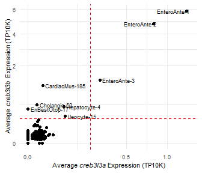

```r
creb_scatter <- ggplot(creb_avg_exp_df, aes(x = creb3l3a, y = creb3l3b, label = Cluster_labs)) + geom_point() + theme_minimal() +
  labs(x = "Average *creb3l3a* Expression (TP10K)", y = "Average *creb3l3b* Expression (TP10K)") +
  geom_text(vjust = "middle", hjust = "inward", nudge_x = 0.02, size = 7, size.unit = "pt") + scale_x_sqrt() + scale_y_sqrt() +
  geom_hline(yintercept = 0.2, color = "red", linetype = "dashed") +
  geom_vline(xintercept = 0.2, color = "red", linetype = "dashed") +
  theme(axis.title.x = ggtext::element_markdown(),axis.title.y = ggtext::element_markdown(), text = element_text(size = 8))
creb_scatter
```

```r
save_plot("260724_creb3l3_atlas_cluster_expression_scatter.svg",creb_scatter, base_height = 3, base_width = 3.5)
```

# Is there effect of creb response type on lrt status

## Make it a table

```r
creb_groups_LRT_table <- creb_groups %>% group_by(Creb3l3_deletion_response, LRT_status) %>%
  summarise(Count = n())
```

```
`summarise()` has regrouped the output.
ℹ Summaries were computed grouped by Creb3l3_deletion_response and LRT_status.
ℹ Output is grouped by Creb3l3_deletion_response.
ℹ Use `summarise(.groups = "drop_last")` to silence this message.
ℹ Use `summarise(.by = c(Creb3l3_deletion_response, LRT_status))` for per-operation grouping instead.
```

# Plot it

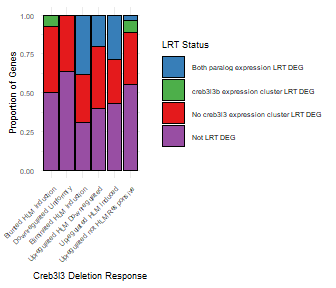

```r
creb_LRT_group_plot <- ggplot(creb_groups_LRT_table, aes(y=Count, x = Creb3l3_deletion_response, fill = LRT_status)) + geom_bar(position = "fill", stat = "identity", color = "black") +
  labs(x = "Creb3l3 Deletion Response", y = "Proportion of Genes", fill = "LRT Status") + theme_minimal() + theme(text = element_text(size = 7, family = "sans"), axis.text.x = element_text(angle = 45, vjust = 1, hjust = 1)) + scale_fill_manual(values = DEG_status_colors)
creb_LRT_group_plot
```

```r
save_plot("260729_LRT_DE_status_by_creb3l3_response_type.svg", creb_LRT_group_plot, base_height = 3, base_width = 3.5)
```

# Run stats to see if that difference in proportion is significant

## Make the contingency table

```r
groups_LRT_cont_table <- creb_groups_LRT_table %>% pivot_wider(names_from = LRT_status, values_from = Count) %>% column_to_rownames("Creb3l3_deletion_response")
```

# Replace NA with 0

```r
groups_LRT_cont_table[is.na(groups_LRT_cont_table)] <- 0
```

```r
fisher.test(groups_LRT_cont_table, simulate.p.value = TRUE)
```

```
    Fisher's Exact Test for Count Data with simulated p-value (based on 2000 replicates)

data:  groups_LRT_cont_table
p-value = 0.07946
alternative hypothesis: two.sided
```

I would have expected significance but I would guess we just have too small a sample size to have enough power

```r
chisq.test(groups_LRT_cont_table)
```

```
    Pearson's Chi-squared test

data:  groups_LRT_cont_table
X-squared = 23.658, df = 15, p-value = 0.07112
```

# Is the overlap between creb3l3 regulated genes and EY specific genes more than expected by random chance

```r
feed_overlap_contingency <- data.frame("Creb3l3" = c(5, 83), "No" = c(9, 32115), row.names = c("EY specific", "No"))
fisher.test(feed_overlap_contingency)
```

```
    Fisher's Exact Test for Count Data

data:  feed_overlap_contingency
p-value = 2.663e-10
alternative hypothesis: true odds ratio is not equal to 1
95 percent confidence interval:
  55.12678 718.14401
sample estimates:
odds ratio
   213.691
```

# Get system information for clusters

```r
annotation_data <- atlas@meta.data %>% group_by(short_cell_type_cluster) %>%
  dplyr::select(c(short_cell_type_cluster, system)) %>% unique()
annotation_data$short_cell_type_cluster <- str_replace_all(annotation_data$short_cell_type_cluster, "_", "-")
annotation_frame <- column_to_rownames(annotation_data, "short_cell_type_cluster")
```

# Determine expression domains for each of the creb3l3 responsive genes

# Make a matrix of just the creb targets TP10K

```r
creb_targets <- rownames(creb_groups) %>% unlist()
creb_targets <- c(creb_targets, "creb3l3a", "creb3l3b")
creb_target_matrix_full <- avg_exp[["RNA"]] %>% as.data.frame()
creb_target_matrix_full <- creb_target_matrix_full[creb_targets,]
creb_target_matrix_full[is.na(creb_target_matrix_full)] <- 0
creb_target_matrix_full <- as.matrix(creb_target_matrix_full)
```

# Remove rows that have only zeros

```r
creb_target_matrix_no_all_zero = creb_target_matrix_full[rowSums(creb_target_matrix_full[])>0,]
```

# What genes am I missing

```r
rownames(creb_target_matrix_no_all_zero)
```

```
 [1] "cry-dash"          "cabp5a"            "acsl4a"            "guk1b"             "uck2a"             "fabp2"             "pias4a"            "crybb1l1"          "atf3"
[10] "inaa"              "apoa1a"            "klf11b"            "ivns1abpb"         "lim2.4"            "crybb1l2"          "serpinh1b"         "usp2a"             "lpin1"
[19] "apoa4b.2.1"        "slc25a55a"         "cryba4"            "btg1"              "elovl4b"           "pfkfb4b"           "crygn2"            "cpa1"              "slc1a8b"
[28] "cryba1l1"          "per2"              "angptl4"           "smox"              "egr1"              "lgals2b"           "tent5ba"           "epb41l4a"          "apoa4b.1"
[37] "cryba2b"           "acad8"             "fabp6"             "opn1sw1"           "aff2"              "arl13a"            "slc25a28"          "crygmx"            "tent5ab"
[46] "sec13"             "ptp4a3b"           "nxf1"              "gde1"              "npas4a"            "per1a"             "crygm2d13"         "dennd2da"          "cish"
[55] "cpt1ab"            "shdb"              "axdnd1"            "zcchc2"            "cry3a"             "six7"              "irs2b"             "fbxl6"             "egr4"
[64] "zmp:0000000845"    "mplkip"            "helq"              "clk4a"             "gpc1b"             "si:ch211-255g12.6" "apoa4b.2"          "nfil3-5"           "si:ch211-276a17.5"
[73] "BX322555.3"        "opn6b"             "dusp2"             "irf2bp2b"          "ftr67"             "si:dkey-61n16.5"   "si:ch211-160f23.7" "hif1al"            "dbt"
[82] "apoea"             "crebbpa"           "CR361564.1"        "hmox2a"            "CABZ01069162.1"    "BX470116.1"        "creb3l3a"          "creb3l3b"
```

```r
creb_targets
```

```
 [1] "cry-dash"          "cabp5a"            "acsl4a"            "guk1b"             "uck2a"             "fabp2"             "pias4a"            "crybb1l1"          "atf3"
[10] "inaa"              "apoa1a"            "klf11b"            "ivns1abpb"         "lim2.4"            "crybb1l2"          "serpinh1b"         "usp2a"             "lpin1"
[19] "apoa4b.2.1"        "slc25a55a"         "cryba4"            "btg1"              "elovl4b"           "pfkfb4b"           "crygn2"            "cpa1"              "slc1a8b"
[28] "cryba1l1"          "per2"              "angptl4"           "smox"              "egr1"              "lgals2b"           "tent5ba"           "epb41l4a"          "apoa4b.1"
[37] "cryba2b"           "acad8"             "fabp6"             "opn1sw1"           "aff2"              "arl13a"            "slc25a28"          "crygmx"            "tent5ab"
[46] "sec13"             "ptp4a3b"           "nxf1"              "gde1"              "npas4a"            "per1a"             "crygm2d13"         "dennd2da"          "si:ch211-216l23.1"
[55] "cish"              "cpt1ab"            "shdb"              "axdnd1"            "zcchc2"            "cry3a"             "six7"              "irs2b"             "fbxl6"
[64] "egr4"              "zmp:0000000845"    "mplkip"            "helq"              "clk4a"             "gpc1b"             "si:ch211-255g12.6" "apoa4b.2"          "nfil3-5"
[73] "si:ch211-276a17.5" "BX322555.3"        "opn6b"             "dusp2"             "irf2bp2b"          "ftr67"             "si:dkey-61n16.5"   "si:ch211-160f23.7" "hif1al"
[82] "dbt"               "apoea"             "crebbpa"           "CR361564.1"        "hmox2a"            "CABZ01069162.1"    "BX470116.1"        "creb3l3a"          "creb3l3b"
```

# Get clusters with creb3l3 expression

```r
creb_target_df_creb_clusters <- as.data.frame(t(creb_target_matrix_full)) %>%
  filter(creb3l3b >= 0.2) %>% as.matrix()
```

# What if I calculate a score that takes into account the usual location and the average expression.

## Use average expression over maximum average expression

```r
max_exp_df<- as.data.frame(creb_target_matrix_no_all_zero) %>%
  rowwise() %>% summarize(Maximum = max(c_across(1:271)))
creb_matrix_max_divided_r <- as.data.frame(creb_target_matrix_no_all_zero) / unlist(max_exp_df)
creb_matrix_max_divided_creb_clusters <- creb_matrix_max_divided_r[,rownames(creb_target_df_creb_clusters)]
creb_matrix_max_divided_r <- as.matrix(creb_matrix_max_divided_r) %>% t()
creb_matrix_max_divided_creb_clusters <- as.matrix(creb_matrix_max_divided_creb_clusters) %>% t()
```

# Identify primary vs. secondary responders

```r
all_targets <- t(creb_matrix_max_divided_creb_clusters) %>%
  as.data.frame() %>%
  rowwise() %>% summarize(Maximum = max(c_across(1:8)))
rownames(all_targets) <- rownames(creb_target_matrix_no_all_zero)
all_targets <- all_targets %>% filter(Maximum >= 0.5) %>% rownames()
aEC_targets <- t(creb_matrix_max_divided_creb_clusters) %>%
  as.data.frame() %>% dplyr::select("EnteroAnte-1", "EnteroAnte-2", "EnteroAnte-3") %>%
  rowwise() %>% summarize(Maximum = max(c_across(1:3)))
rownames(aEC_targets) <- rownames(creb_target_matrix_no_all_zero)
aEC_targets <- aEC_targets %>% filter(Maximum >= 0.5) %>% rownames()
creb3l3b_targets <- setdiff(all_targets, aEC_targets)
secondary <- setdiff(creb_targets, all_targets)
```

```r
aEC_targets
```

```
 [1] "acsl4a"         "fabp2"          "atf3"           "apoa1a"         "apoa4b.2.1"     "angptl4"        "apoa4b.1"       "sec13"          "cpt1ab"         "cry3a"          "zmp:0000000845"
[12] "clk4a"          "apoa4b.2"       "dbt"            "apoea"          "crebbpa"        "creb3l3a"       "creb3l3b"
```

```r
creb3l3b_targets
```

```
[1] "lpin1"          "acad8"          "fabp6"          "per1a"          "irf2bp2b"       "ftr67"          "CABZ01069162.1"
```

```r
secondary
```

```
 [1] "cry-dash"          "cabp5a"            "guk1b"             "uck2a"             "pias4a"            "crybb1l1"          "inaa"              "klf11b"            "ivns1abpb"
[10] "lim2.4"            "crybb1l2"          "serpinh1b"         "usp2a"             "slc25a55a"         "cryba4"            "btg1"              "elovl4b"           "pfkfb4b"
[19] "crygn2"            "cpa1"              "slc1a8b"           "cryba1l1"          "per2"              "smox"              "egr1"              "lgals2b"           "tent5ba"
[28] "epb41l4a"          "cryba2b"           "opn1sw1"           "aff2"              "arl13a"            "slc25a28"          "crygmx"            "tent5ab"           "ptp4a3b"
[37] "nxf1"              "gde1"              "npas4a"            "crygm2d13"         "dennd2da"          "si:ch211-216l23.1" "cish"              "shdb"              "axdnd1"
[46] "zcchc2"            "six7"              "irs2b"             "fbxl6"             "egr4"              "mplkip"            "helq"              "gpc1b"             "si:ch211-255g12.6"
[55] "nfil3-5"           "si:ch211-276a17.5" "BX322555.3"        "opn6b"             "dusp2"             "si:dkey-61n16.5"   "si:ch211-160f23.7" "hif1al"            "CR361564.1"
[64] "hmox2a"            "BX470116.1"
```

```r
aEC_targets <- aEC_targets[! aEC_targets %in% c("creb3l3a", "creb3l3b")]
```

```r
aEC_targets
```

```
 [1] "acsl4a"         "fabp2"          "atf3"           "apoa1a"         "apoa4b.2.1"     "angptl4"        "apoa4b.1"       "sec13"          "cpt1ab"         "cry3a"          "zmp:0000000845"
[12] "clk4a"          "apoa4b.2"       "dbt"            "apoea"          "crebbpa"
```

# Add primary target-ness to the gene annotations

```r
creb_groups <- rownames_to_column(creb_groups, var = "gene") %>%
  mutate(Expression_location = case_when(
    gene %in% aEC_targets ~ "Both paralog expression region",
    gene %in% creb3l3b_targets ~ "creb3l3b expression region",
    gene %in% secondary ~ "No creb3l3 expression region",
    gene %in% c("creb3l3a", "creb3l3b") ~ "creb3l3 paralog",
    .default = "Not found in snRNA-seq"
  )) %>%
  column_to_rownames(var = "gene")
```

# Plot it

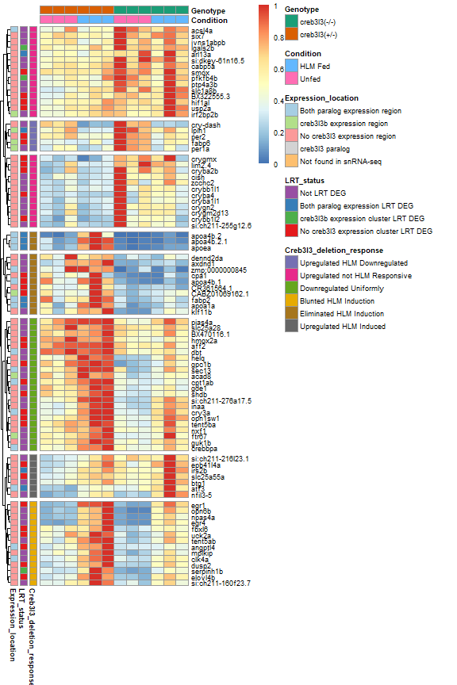

```r
h3 <- pheatmap(creb_matrix_max_divided, cluster_cols = FALSE, annotation_col = columnData, annotation_row = creb_groups, scale = "none", cutree_rows = 8, fontsize = 7, treeheight_row = 4, show_colnames = FALSE, annotation_colors = list(Genotype = genotype_colors, Condition = c("HLM Fed" = "steelblue1", "Unfed" = "hotpink1"), Creb3l3_deletion_response = creb_response_colors, LRT_status = DEG_status_colors, Expression_location = Expression_location_colors))
```

# What if I call expression region based on TP10K (this is probably better)

```r
all_targets_2 <- t(creb_target_df_creb_clusters) %>%
  as.data.frame() %>%
  rowwise() %>% summarize(Maximum = max(c_across(1:8)))
rownames(all_targets_2) <- rownames(creb_target_matrix_full)
all_targets_2 <- all_targets_2 %>% filter(Maximum >= 0.2) %>% rownames()
aEC_targets_2 <- t(creb_target_df_creb_clusters) %>%
  as.data.frame() %>% dplyr::select("EnteroAnte-1", "EnteroAnte-2", "EnteroAnte-3") %>%
  rowwise() %>% summarize(Maximum = max(c_across(1:3)))
rownames(aEC_targets_2) <- rownames(creb_target_matrix_full)
aEC_targets_2 <- aEC_targets_2 %>% filter(Maximum >= 0.2) %>% rownames()
creb3l3b_targets_2 <- setdiff(all_targets_2, aEC_targets_2)
secondary_2 <- setdiff(creb_targets, all_targets_2)
```

```r
aEC_targets_2
```

```
 [1] "acsl4a"     "fabp2"      "atf3"       "apoa1a"     "lpin1"      "apoa4b.2.1" "slc25a55a"  "btg1"       "cryba1l1"   "per2"       "angptl4"    "lgals2b"    "tent5ba"    "apoa4b.1"
[15] "fabp6"      "opn1sw1"    "aff2"       "slc25a28"   "dennd2da"   "cpt1ab"     "cry3a"      "irs2b"      "clk4a"      "apoa4b.2"   "hif1al"     "apoea"      "crebbpa"    "creb3l3a"
[29] "creb3l3b"
```

```r
aEC_targets
```

```
 [1] "acsl4a"         "fabp2"          "atf3"           "apoa1a"         "apoa4b.2.1"     "angptl4"        "apoa4b.1"       "sec13"          "cpt1ab"         "cry3a"          "zmp:0000000845"
[12] "clk4a"          "apoa4b.2"       "dbt"            "apoea"          "crebbpa"
```

```r
creb3l3b_targets_2
```

```
 [1] "crybb1l1"          "crybb1l2"          "serpinh1b"         "usp2a"             "cryba4"            "pfkfb4b"           "crygn2"            "cryba2b"           "arl13a"
[10] "crygm2d13"         "cish"              "si:ch211-255g12.6" "CABZ01069162.1"
```

```r
creb3l3b_targets
```

```
[1] "lpin1"          "acad8"          "fabp6"          "per1a"          "irf2bp2b"       "ftr67"          "CABZ01069162.1"
```

```r
secondary_2
```

```
 [1] "cry-dash"          "cabp5a"            "guk1b"             "uck2a"             "pias4a"            "inaa"              "klf11b"            "ivns1abpb"         "lim2.4"
[10] "elovl4b"           "cpa1"              "slc1a8b"           "smox"              "egr1"              "epb41l4a"          "acad8"             "crygmx"            "tent5ab"
[19] "sec13"             "ptp4a3b"           "nxf1"              "gde1"              "npas4a"            "per1a"             "si:ch211-216l23.1" "shdb"              "axdnd1"
[28] "zcchc2"            "six7"              "fbxl6"             "egr4"              "zmp:0000000845"    "mplkip"            "helq"              "gpc1b"             "nfil3-5"
[37] "si:ch211-276a17.5" "BX322555.3"        "opn6b"             "dusp2"             "irf2bp2b"          "ftr67"             "si:dkey-61n16.5"   "si:ch211-160f23.7" "dbt"
[46] "CR361564.1"        "hmox2a"            "BX470116.1"
```

```r
secondary
```

```
 [1] "cry-dash"          "cabp5a"            "guk1b"             "uck2a"             "pias4a"            "crybb1l1"          "inaa"              "klf11b"            "ivns1abpb"
[10] "lim2.4"            "crybb1l2"          "serpinh1b"         "usp2a"             "slc25a55a"         "cryba4"            "btg1"              "elovl4b"           "pfkfb4b"
[19] "crygn2"            "cpa1"              "slc1a8b"           "cryba1l1"          "per2"              "smox"              "egr1"              "lgals2b"           "tent5ba"
[28] "epb41l4a"          "cryba2b"           "opn1sw1"           "aff2"              "arl13a"            "slc25a28"          "crygmx"            "tent5ab"           "ptp4a3b"
[37] "nxf1"              "gde1"              "npas4a"            "crygm2d13"         "dennd2da"          "si:ch211-216l23.1" "cish"              "shdb"              "axdnd1"
[46] "zcchc2"            "six7"              "irs2b"             "fbxl6"             "egr4"              "mplkip"            "helq"              "gpc1b"             "si:ch211-255g12.6"
[55] "nfil3-5"           "si:ch211-276a17.5" "BX322555.3"        "opn6b"             "dusp2"             "si:dkey-61n16.5"   "si:ch211-160f23.7" "hif1al"            "CR361564.1"
[64] "hmox2a"            "BX470116.1"
```

```r
aEC_targets_2 <- aEC_targets_2[! aEC_targets %in% c("creb3l3a", "creb3l3b")]
```

# Add primary target-ness to the gene annotations

```r
creb_groups <- rownames_to_column(creb_groups, var = "gene") %>%
  mutate(Expression_location = case_when(
    gene %in% aEC_targets_2 ~ "Both paralog expression region",
    gene %in% creb3l3b_targets_2 ~ "creb3l3b expression region",
    gene %in% secondary_2 ~ "No creb3l3 expression region",
    gene %in% c("creb3l3a", "creb3l3b") ~ "creb3l3 paralog",
  )) %>%
  column_to_rownames(var = "gene")
```

# Plot it

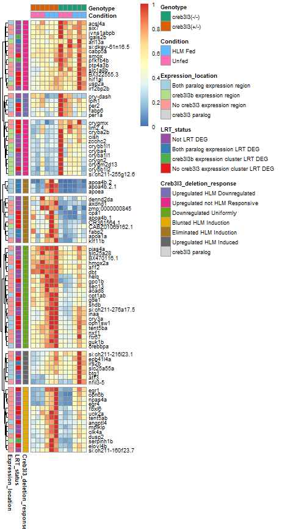

```r
h4 <- pheatmap(creb_matrix_max_divided, cluster_cols = FALSE, annotation_col = columnData, annotation_row = creb_groups, scale = "none", cutree_rows = 8, fontsize = 7, treeheight_row = 4, show_colnames = FALSE, annotation_colors = list(Genotype = genotype_colors, Condition = c("HLM Fed" = "steelblue1", "Unfed" = "hotpink1"), Creb3l3_deletion_response = creb_response_colors, LRT_status = DEG_status_colors, Expression_location = Expression_location_colors))
```

```r
save_plot("260729_creb3l3_bulk_expression_heatmap.svg", h4, base_height = 9, base_width = 5)
```

# Make an annotation data frame that includes the creb3l3 genes

```r
creb_ann <- data.frame("Creb3l3_deletion_response" = c("creb3l3 paralog", "creb3l3 paralog"), LRT_status = c("Both paralog expression LRT DEG", "Not LRT DEG"), Expression_location = c("creb3l3 paralog", "creb3l3 paralog"), row.names = c("creb3l3a", "creb3l3b"))
creb_annotations <- rbind(creb_groups, creb_ann)
creb_annotations <- creb_annotations[rownames(creb_target_matrix_no_all_zero),]
```

# Heatmap of snRNA-seq expression for these genes

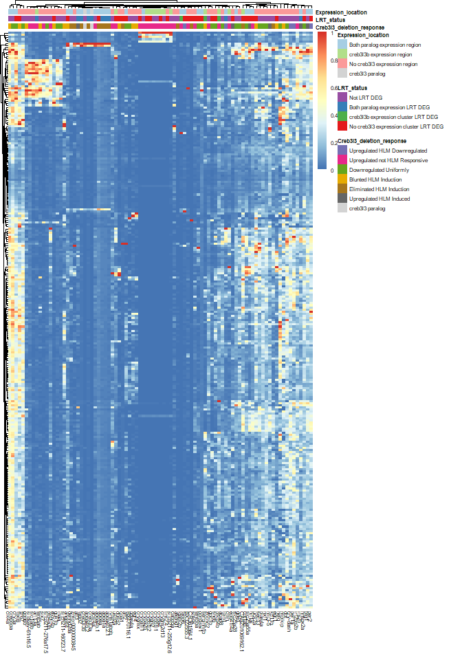

```r
pheatmap(creb_matrix_max_divided_r, annotation_col = creb_annotations, annotation_colors = list(Creb3l3_deletion_response = creb_response_colors, LRT_status = DEG_status_colors, Expression_location = Expression_location_colors), show_rownames = FALSE, fontsize = 6, treeheight_row = 4, treeheight_col = 4)
```

# What if I plot the straight TP10K values on a square root color scale (accomplished by making a square rooted matrix and the relabeling the color scale)

## Make square root matrix

```r
creb_matrix_sqrt <- sqrt(creb_target_matrix_no_all_zero)
```

## Plot it

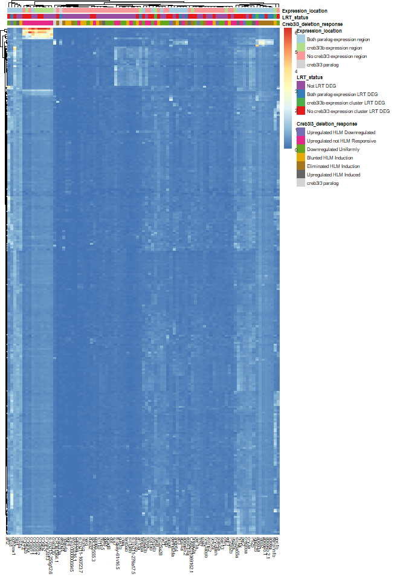

```r
pheatmap(t(creb_matrix_sqrt), annotation_col = creb_annotations, annotation_colors = list(Creb3l3_deletion_response = creb_response_colors, LRT_status = DEG_status_colors, Expression_location = Expression_location_colors), show_rownames = FALSE, fontsize = 6, treeheight_row = 4, treeheight_col = 4)
```

# What about log10 scale

## Make log10 matrix

```r
creb_matrix_log10 <- log10(creb_target_matrix_no_all_zero)
creb_matrix_log10[creb_matrix_log10 == -Inf] <- -4
```

## Reorder matrix in creb3l3b expression order

```r
creb_matrix_log10 <- t(creb_matrix_log10) %>% as.data.frame() %>% arrange(desc(creb3l3b)) %>% as.matrix()
```

# Reorder matrix columns based on creb response patterns

```r
col_order <- h4$tree_row$labels[h4$tree_row$order]
col_order <- c(col_order, "creb3l3a", "creb3l3b")
col_order <- col_order[col_order != "si:ch211-216l23.1"]
creb_matrix_log10 <- creb_matrix_log10[,col_order]
```

# Get system colors and annotaions

```r
annotation_data <- column_to_rownames(annotation_data, var = "short_cell_type_cluster")
system_colors <- c("connective tissue" = "#22FAFC", "sensory" = "#FB00FB", "musculoskeletal" = "#E6E90D", "digestive" = "#4B4D53", "transporter" = "#EE2200", "nervous" = "#267CFE", "integumentary" = "#FF7EAD", "cardiovascular" = "#00FB7E", "respiratory" = "#F5960D", "neural crest" = "#DCA3FB", "unknown" = "#FFDCBB", "endocrine" = "#407C0D", "immune" = "#0D85BA", "pronephric" = "#7C420D")
```

## Plot it

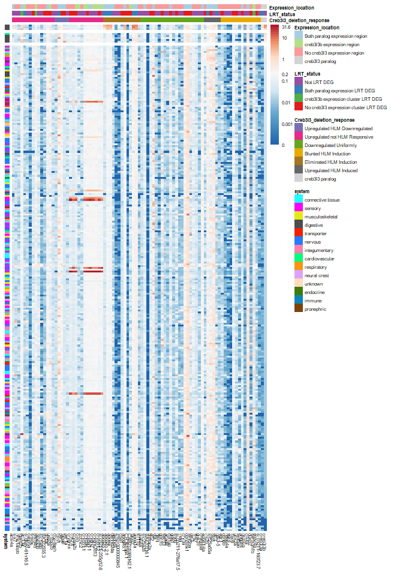

```r
h5 <- pheatmap(creb_matrix_log10, annotation_col = creb_annotations, annotation_colors = list(Creb3l3_deletion_response = creb_response_colors, LRT_status = DEG_status_colors, Expression_location = Expression_location_colors, system = system_colors), show_rownames = FALSE, fontsize = 6, treeheight_row = 4, treeheight_col = 4, color = colorRampPalette(rev(brewer.pal(n = 7, name = "RdBu")), bias = 0.75)(50), cluster_rows = FALSE, legend_breaks = c(-4, -3, -2, -1, -0.7, 0, 1, 1.5), legend_labels = c(0, 0.001, 0.01, 0.1, 0.2, 1, 10, 31.6), gaps_row = c(3, 8), cluster_cols = FALSE, annotation_row = annotation_data)
```

```r
save_plot("260729_creb3l3_responsive_gene_expression_snRNA_TP10K.svg", h5, base_width = 7, base_height = 10)
```